# State MSM Profile: **Minnesota**

### Background & Methods

In 2015-2016, researchers at Emory University partnered with colleagues at the Centers for Disease Control and Prevention (CDC) to develop methods to estimate the number of men who have sex with men (MSM) residing in each county in the United States. Using population and housing data from the [American Community Survey](https://www.census.gov/programs-surveys/acs/) and estimates from two peer-reviewed publications ([Oster et al., 2015](http://www.ncbi.nlm.nih.gov/pubmed/26115985) & [Purcell et al., 2012](http://www.ncbi.nlm.nih.gov/pubmed/23049658)), they derived an indirect estimate of MSM population sizes that took into account both the urbanicity of the county as well as its density of households with a male householder and a male same-sex partner.

The full methodology is published in the *Journal of Medical Internet Research - Public Health and Surveillance*:

> [Grey JA, Bernstein KT, Sullivan PS, Purcell DW, Chesson HW, Gift TL, Rosenberg ES. Estimating the population sizes of men who have sex with men in US states and counties using data from the American Community Survey. JMIR Public Health Surveill 2016;2(1):e14. DOI: 10.2196/publichealth.5365](http://publichealth.jmir.org/2016/1/e14/)

### Overview of MSM in Minnesota

An estimated **83,027** men who have sex with men (MSM) resided in Minnesota in 2013, representing 1.8% of the 4,503,084 MSM in the United States. Of the 2,000,472 adult men of Minnesota, 4.2% had had sex with another man in the past 5 years, which was greater than the overall percentage of adult men in the United States who were MSM (3.9%).

Most MSM in Minnesota resided in central counties of large metropolitan areas (59.5%). Including both central and fringe counties, 84.0% resided in a large metropolitan area.

##### **Percentage of MSM by urbanicity, United States and Minnesota, 2013**

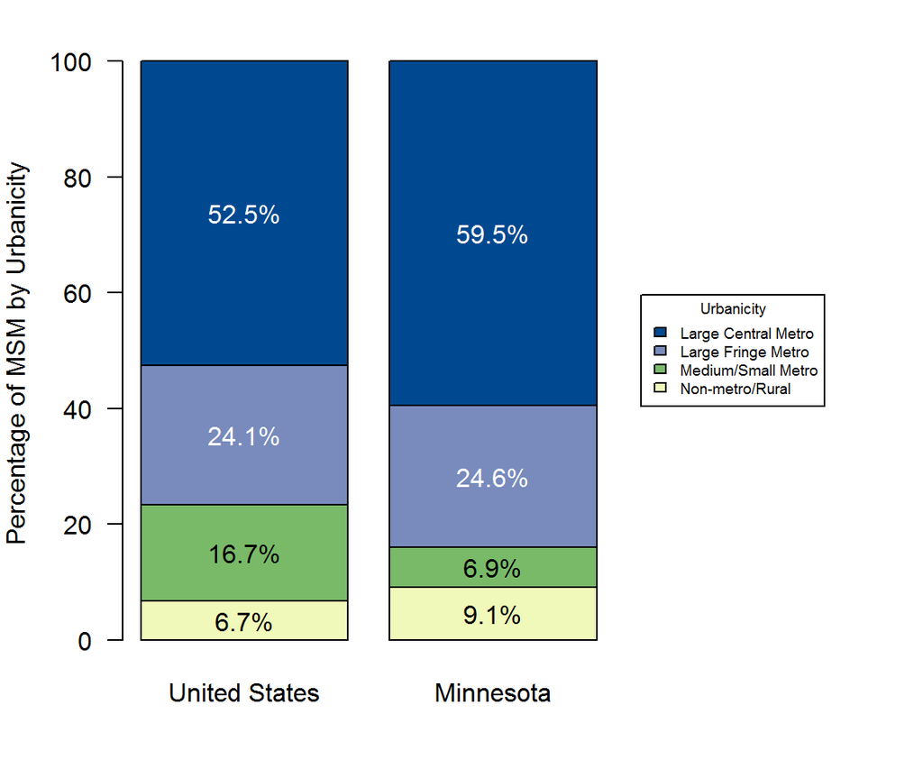

### MSM in Minnesota Counties

Among counties or county-equivalent areas in Minnesota, Hennepin County had the largest population of MSM at 37,610, representing 45.3% of all MSM in the state. Hennepin County also had the highest percentage of MSM among adult men in Minnesota at 8.5%. This was greater than the percentage for Minnesota as a whole, which was 4.2% of adult men.

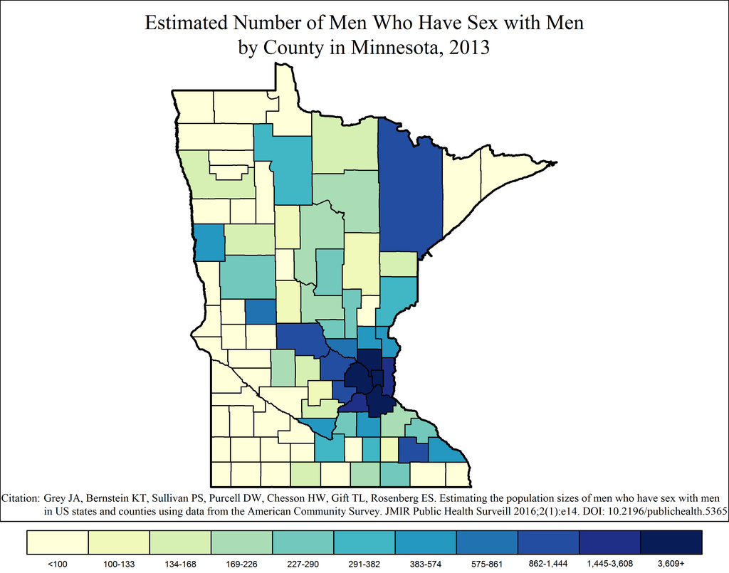

Note: Range cutpoints for the map are based on the distribution of MSM among all counties in the United States.

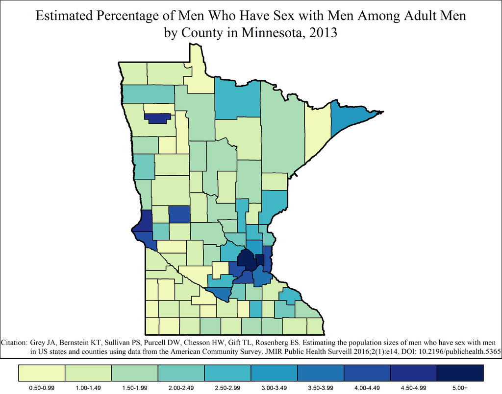

### MSM in Minnesota Metropolitan Statistical Areas

#### Minneapolis-St. Paul-Bloomington Metropolitan Statistical Area

The Minneapolis-St. Paul-Bloomington MSA overlaps two states: Minnesota and Wisconsin. The Minnesota portion of the MSA had the largest metropolitan population of MSM in Minnesota at 69,776, or 84.0% of all MSM in the state and 98.1% of the 71,099 MSM in the MSA. Of the 1,201,298 adult men in the Minnesota part of Minneapolis-St. Paul-Bloomington, an estimated 5.8% were MSM. This was greater than the percentage of MSM among adult men in the MSA as a whole, which was 5.7% of adult men (71,099 out of 1,247,688).

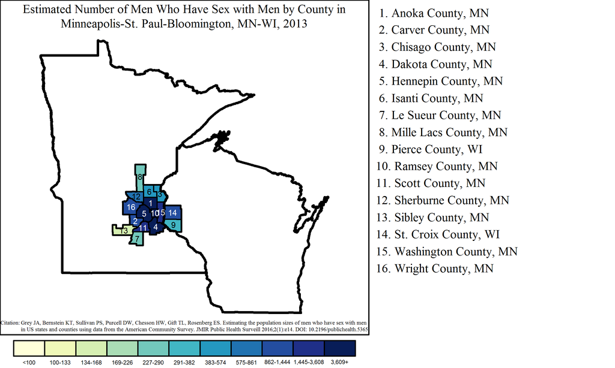

Note: Range cutpoints for the map are based on the distribution of MSM among all counties in the United States.

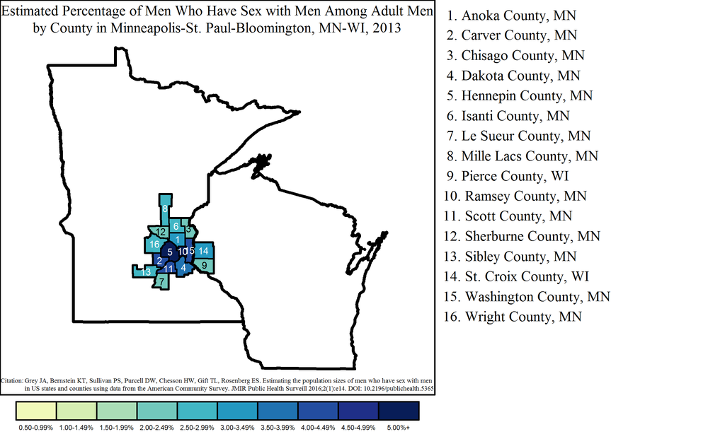

#### Rochester Metropolitan Statistical Area

The Rochester MSA had a population of 1,618 MSM, or 1.9% of all MSM in Minnesota. Of the 75,901 adult men in Rochester, an estimated 2.1% were MSM.

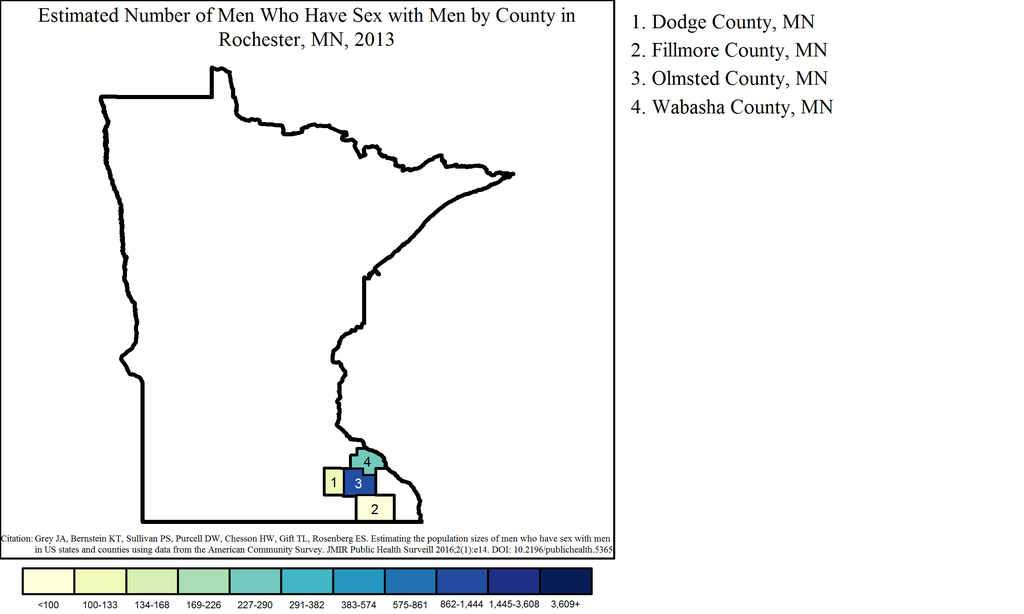

Note: Range cutpoints for the map are based on the distribution of MSM among all counties in the United States.

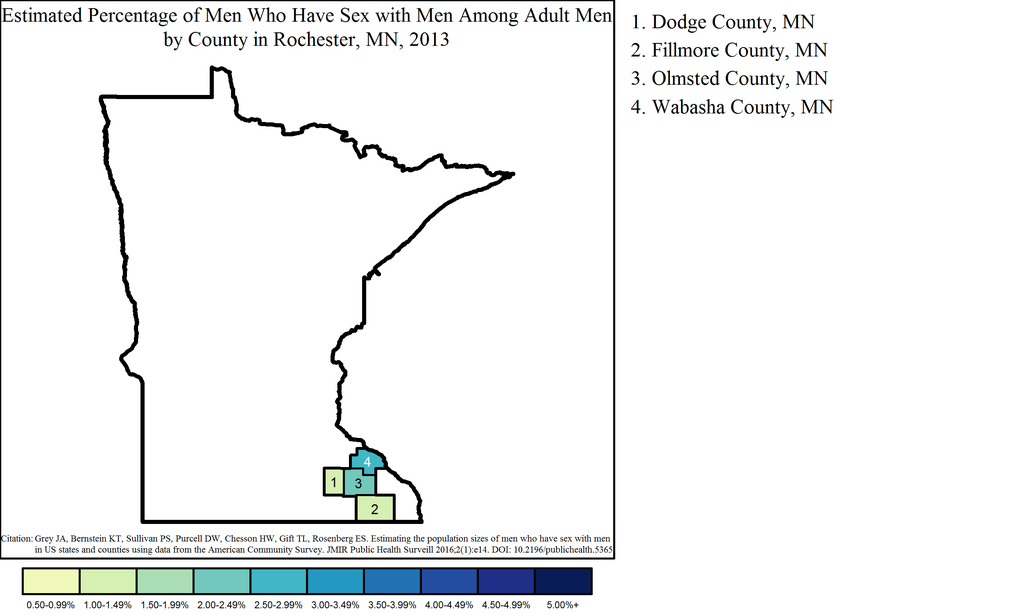

#### Duluth Metropolitan Statistical Area

The Duluth MSA overlaps two states: Minnesota and Wisconsin. The Minnesota portion of the MSA had 1,400 MSM, or 1.7% of all MSM in the state and 79.9% of the 1,752 MSM in the MSA. Of 94,511 adult men in the Minnesota part of Duluth, 1.5% were MSM. This was less than the overall percentage of MSM among adult men in the MSA, which was 1.6% of adult men (1,752 out of 111,691).

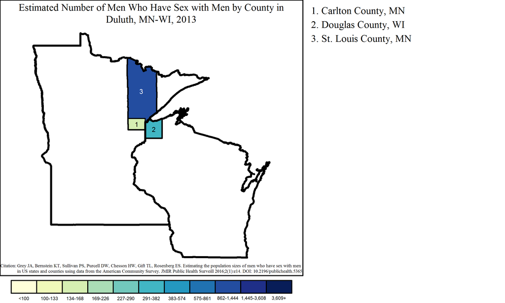

Note: Range cutpoints for the map are based on the distribution of MSM among all counties in the United States.

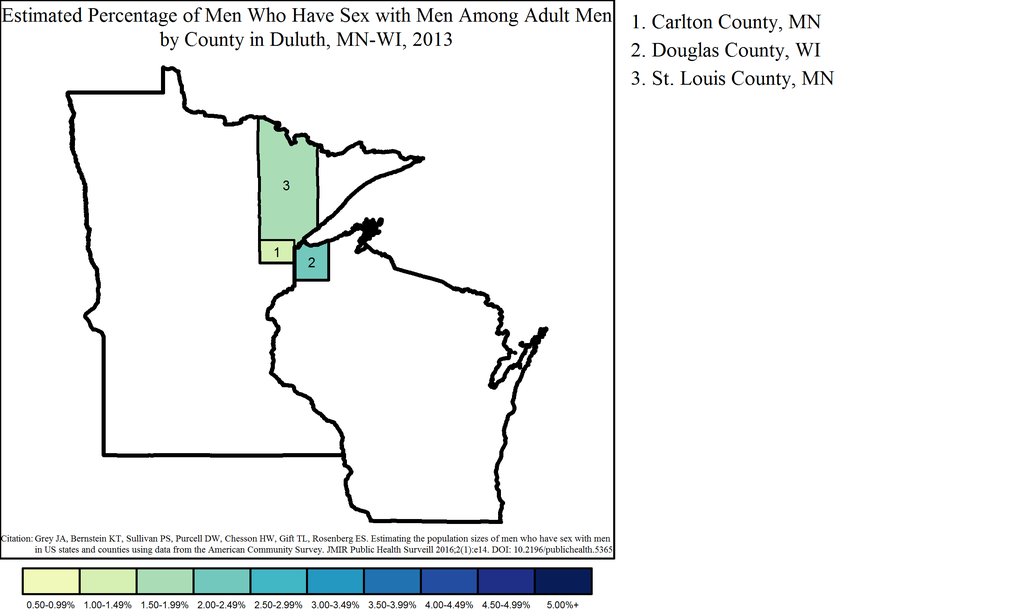

#### St. Cloud Metropolitan Statistical Area

The St. Cloud MSA had a population of 1,183 MSM, or 1.4% of all MSM in Minnesota. Of the 72,920 adult men in St. Cloud, an estimated 1.6% were MSM.

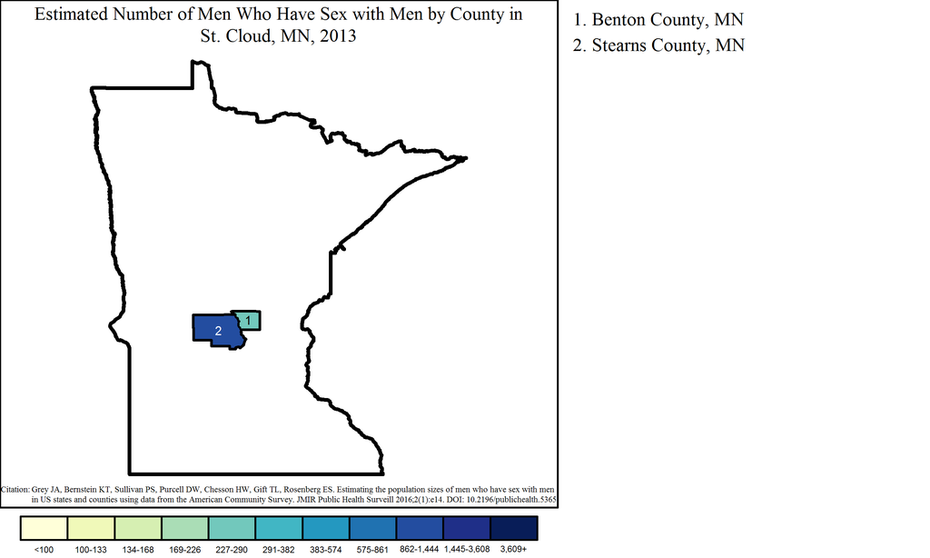

Note: Range cutpoints for the map are based on the distribution of MSM among all counties in the United States.

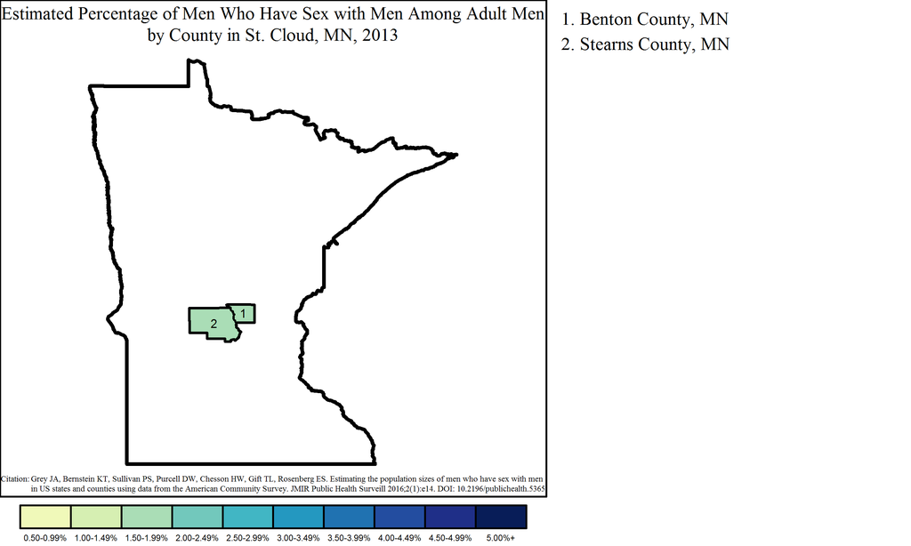

#### Mankato-North Mankato Metropolitan Statistical Area

The Mankato-North Mankato MSA had a population of 810 MSM, or 1.0% of all MSM in Minnesota. Of the 38,613 adult men in Mankato-North Mankato, an estimated 2.1% were MSM.

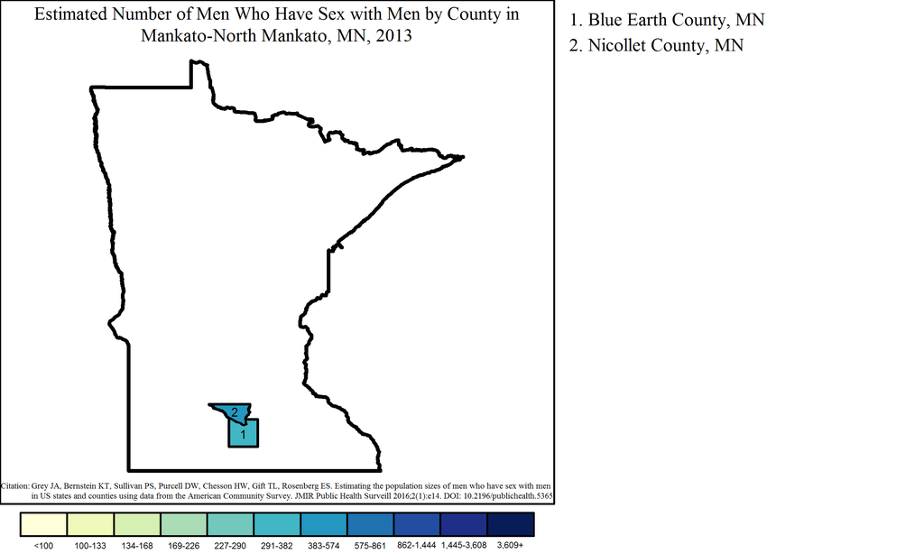

Note: Range cutpoints for the map are based on the distribution of MSM among all counties in the United States.

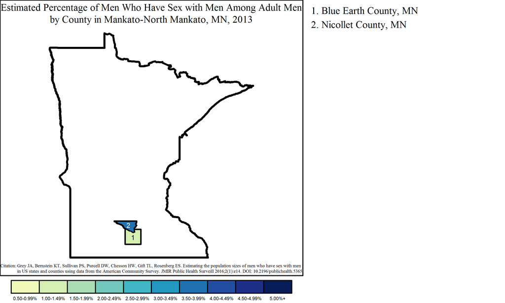

#### Fargo Metropolitan Statistical Area

The Fargo MSA overlaps two states: Minnesota and North Dakota. The Minnesota portion of the MSA had 475 MSM, or 0.6% of all MSM in the state and 29.8% of the 1,595 MSM in the MSA. Of 22,325 adult men in the Minnesota part of Fargo, 2.1% were MSM. This was greater than the overall percentage of MSM among adult men in the MSA, which was 1.9% of adult men (1,595 out of 82,978).

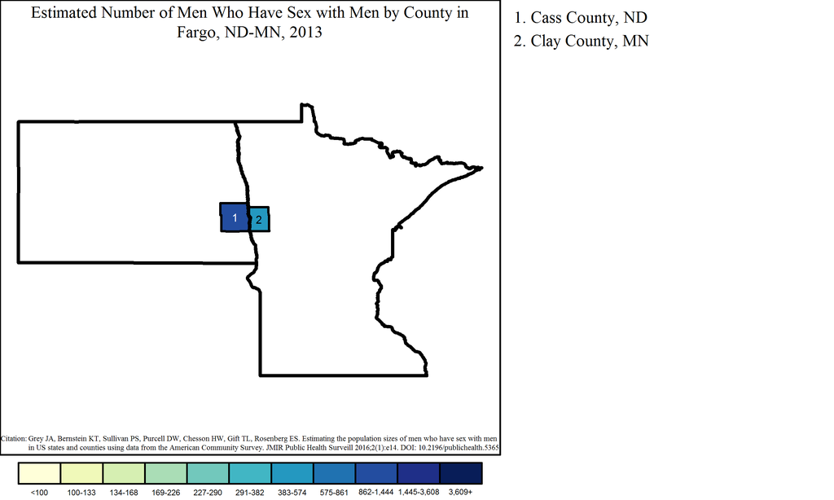

Note: Range cutpoints for the map are based on the distribution of MSM among all counties in the United States.

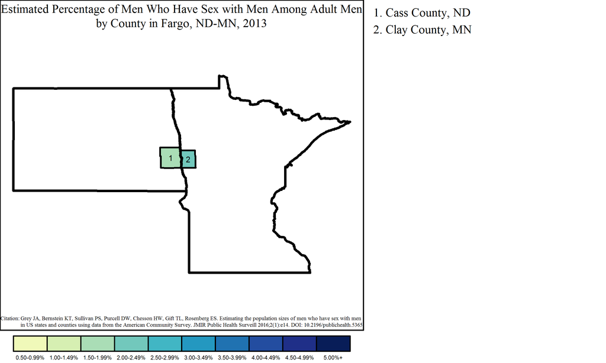

#### Grand Forks Metropolitan Statistical Area

The Grand Forks MSA overlaps two states: Minnesota and North Dakota. The Minnesota portion of the MSA had 158 MSM, or 0.2% of all MSM in the state and 22.6% of the 700 MSM in the MSA. Of 12,107 adult men in the Minnesota part of Grand Forks, 1.3% were MSM. This was less than the overall percentage of MSM among adult men in the MSA, which was 1.8% of adult men (700 out of 39,794).

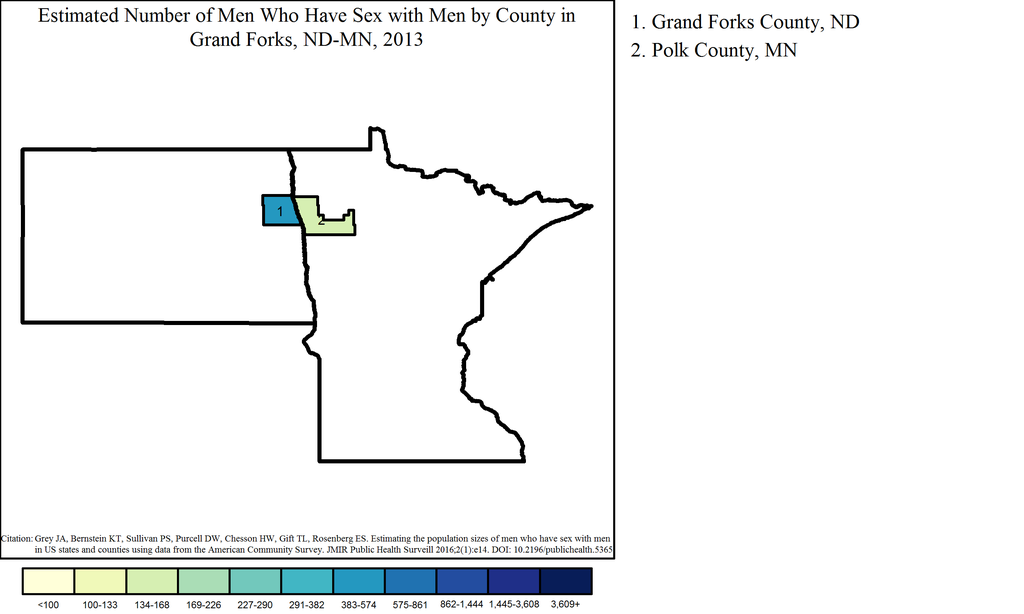

Note: Range cutpoints for the map are based on the distribution of MSM among all counties in the United States.

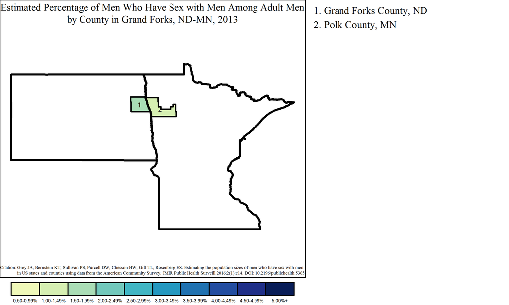

#### La Crosse-Onalaska Metropolitan Statistical Area

The La Crosse-Onalaska MSA overlaps two states: Minnesota and Wisconsin. The Minnesota portion of the MSA had 89 MSM, or 0.1% of all MSM in the state and 9.0% of the 984 MSM in the MSA. Of 7,234 adult men in the Minnesota part of La Crosse-Onalaska, 1.2% were MSM. This was less than the overall percentage of MSM among adult men in the MSA, which was 1.9% of adult men (984 out of 51,120).

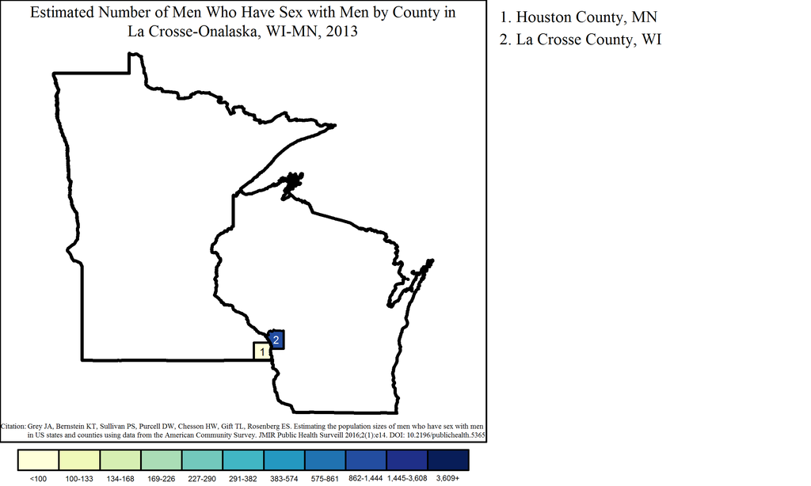

Note: Range cutpoints for the map are based on the distribution of MSM among all counties in the United States.

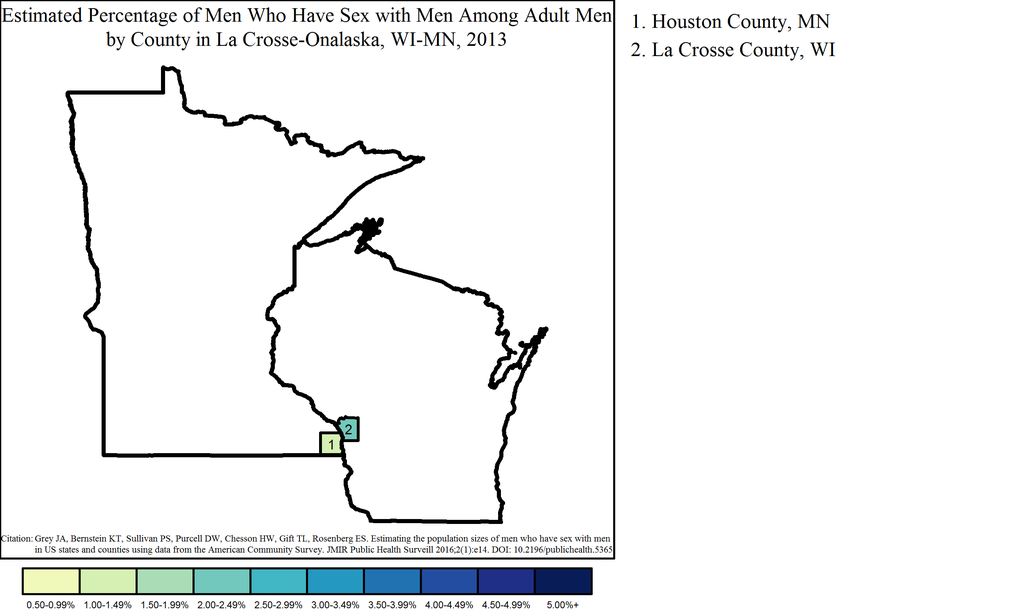